# Servicio de bicis en NYC

Veamos las ubicaciones de las estaciones en un mapa de la ciudad. # Mapa Stations

```r
library(leaflet)
library(magrittr)
stations <- readr::read_csv("dat/stations.csv")
colnames(stations)
```

```
[1] "X1"                "station.id"        "station.name"      "station.latitude"
[5] "station.longitude"
```

```r
colnames(stations) <- c("X1","station.id","station.name","latitude","longitude")
names(providers)
```

[output not shown]

[output cut: 67 more lines]

```r
leaflet(options = leafletOptions(minZoom = 0, maxZoom = 18))
```

[interactive chart not shown]

```r
m1 <- leaflet(stations) %>%
  addTiles() %>% addProviderTiles(providers$MtbMap) %>%
  addProviderTiles(providers$Stamen.TonerLines,
    options = providerTileOptions(opacity = 0.35)) %>%
  addProviderTiles(providers$Stamen.TonerLabels)
m1 %>%
  addCircles(color = "red",radius=5, opacity = T ) %>%
  addMarkers(popup = ~htmltools::htmlEscape(station.name))
```

```
Assuming "longitude" and "latitude" are longitude and latitude, respectively
Assuming "longitude" and "latitude" are longitude and latitude, respectively
```

[interactive chart not shown]

Usuarios por edades y género. # Análisis de usuarios

```r
rutas <- readr::read_csv("dat/bike_nyc_1_6_2019.csv")
colnames(rutas)
```

```
[1] "tripduration"     "starttime"        "stoptime"         "start.station.id"
[5] "end.station.id"   "bikeid"           "usertype"         "birth.year"
[9] "gender"
```

```r
usuarios <- rutas %>% dplyr::select(birth.year,gender,usertype) %>%
  dplyr::mutate(age = lubridate::year(Sys.Date())-birth.year) %>%
  dplyr::group_by(age,gender,usertype) %>%
  dplyr::mutate(contador = n()) %>%
  dplyr::group_by(age,gender,contador,usertype) %>%
  dplyr::summarise()
```

```
Calling `n()` without importing or prefixing it is deprecated, use `dplyr::n()`.
```

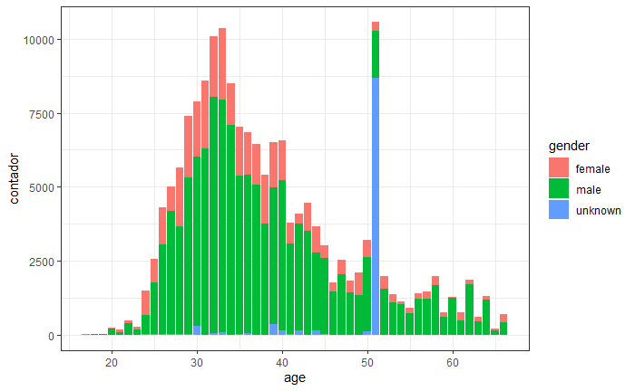

```r
usuarios %>%
  ggplot2::ggplot(ggplot2::aes(x = age, y = contador,fill=gender))+
  ggplot2::geom_col()+
  ggplot2::theme_bw()
```

```r
NA
NA
```

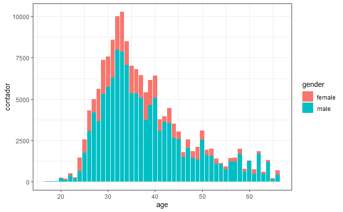

```r
usuarios %>%
  dplyr::filter(gender!="unknown") %>%
  ggplot2::ggplot(ggplot2::aes(x = age, y = contador,fill=gender))+
  ggplot2::geom_col()+
  ggplot2::theme_bw()
```

Se ve que hay un uso del servicio de bicis mucho mayor por parte de hombres que de mujeres. La franja de edad de mayor uso está entre los 31 y los 34 años.

Vamos a ver sólo las mujeres junto al tipo de usuario.

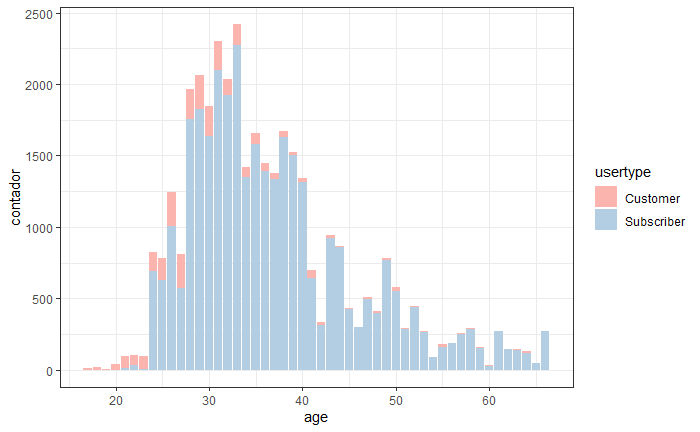

Y los hombres…

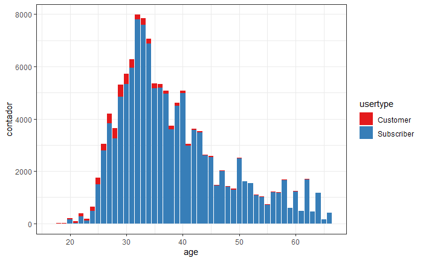

Veamos la distribución que sigue la duración de los viajes. # Duración de los viajes

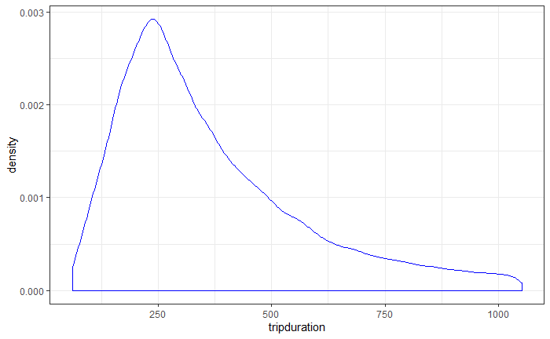

```r
rutas %>% dplyr::select(tripduration) %>%
  ggplot2::ggplot(ggplot2::aes(x=tripduration))+
  ggplot2::geom_density(colour="blue")+
  ggplot2::theme_bw()
```

Veamos como se distribuye la duración media de los viajes y la relación entre dicha duración media y la frecuencia de uso de las rutas.

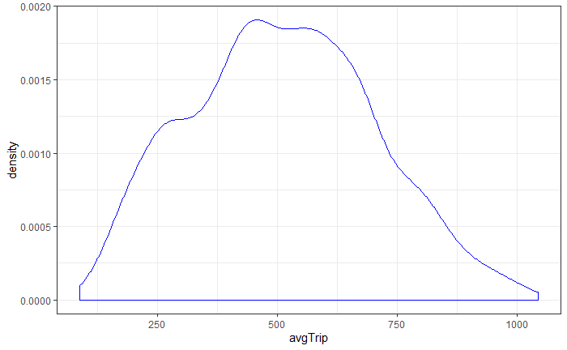

```r
resumen_rutas <- rutas %>%
  tidyr::unite(ruta, start.station.id,end.station.id,sep="-") %>%
  dplyr::group_by(ruta) %>%
  dplyr::summarise(contador = dplyr::n(),
                   avgTrip = mean(tripduration)) %>%
  dplyr::arrange(desc(avgTrip)) %>%
  dplyr::ungroup()

resumen_rutas %>%
  dplyr::select(avgTrip) %>%
  ggplot2::ggplot(ggplot2::aes(x=avgTrip))+
  ggplot2::geom_density(colour="blue")+
  ggplot2::theme_bw()
```

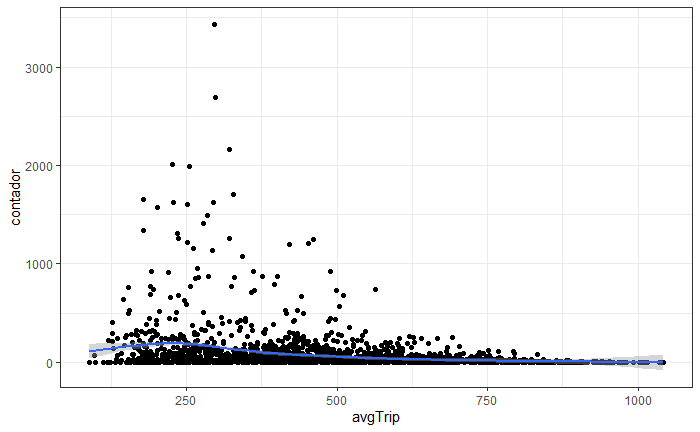

```r
resumen_rutas %>%
  ggplot2::ggplot()+
  ggplot2::geom_point(ggplot2::aes(x=avgTrip,y=contador))+
  ggplot2::geom_smooth(ggplot2::aes(x=avgTrip,y=contador))+
  ggplot2::theme_bw()
```

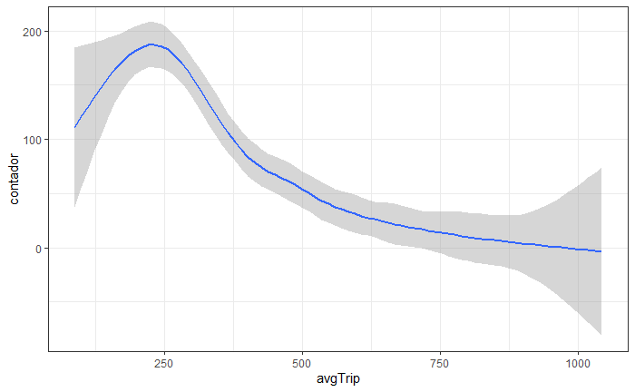

```r
resumen_rutas %>%
  ggplot2::ggplot()+
  ggplot2::geom_smooth(ggplot2::aes(x=avgTrip,y=contador))+
  ggplot2::theme_bw()
```

```r
summary(resumen_rutas$avgTrip)
```

```
   Min. 1st Qu.  Median    Mean 3rd Qu.    Max.
   88.0   372.5   506.5   510.9   647.4  1043.0
```

# Pendiente

```r
stations_geo <- stations %>%
  tidyr::unite(lat_long,latitude,longitude,sep="+")


rutas_geo <- rutas %>%
  dplyr::right_join(stations_geo,by=c("start.station.id"="station.id")) %>%
  dplyr::rename(origin_lat_long=lat_long) %>%
  dplyr::right_join(stations_geo,by=c("end.station.id"="station.id")) %>%
  dplyr::rename(end_lat_long=lat_long,station.name.ori=station.name.x,station.name.end=station.name.y) %>%
  dplyr::select(-c(10,13)) %>%
  tidyr::unite(ruta, start.station.id,end.station.id,sep="-")
```

Estaciones con más uso (80% de los usos) # Uso de estaciones

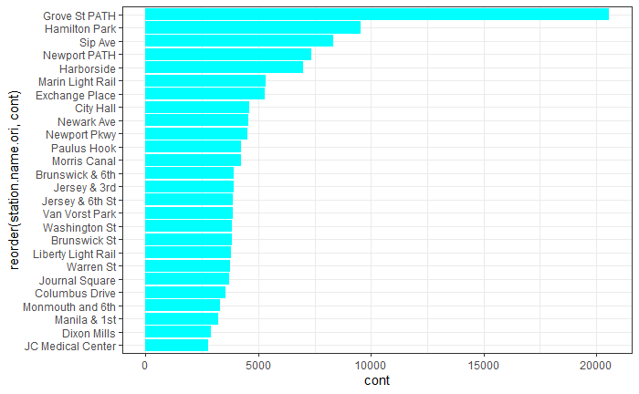

```r
start_stations <- rutas_geo %>%
  dplyr::group_by(station.name.ori) %>%
  dplyr::summarise(cont = n()) %>%
  dplyr::arrange(desc(cont)) %>%
  dplyr::mutate(acumulado=cumsum(cont)) %>%
  dplyr::inner_join(stations,c("station.name.ori"="station.name")) %>%
  dplyr::filter(acumulado<0.8*nrow(rutas_geo))

end_stations <- rutas_geo %>%
  dplyr::group_by(station.name.end) %>%
  dplyr::summarise(cont = n()) %>%
  dplyr::arrange(desc(cont)) %>%
  dplyr::mutate(acumulado=cumsum(cont)) %>%
  dplyr::inner_join(stations,by=c("station.name.end"="station.name")) %>%
  dplyr::filter(acumulado<0.8*nrow(rutas_geo))

start_stations %>%
  ggplot2::ggplot(ggplot2::aes(x = reorder(station.name.ori,cont),y=cont))+
  ggplot2::geom_col(fill="cyan")+
  ggplot2::coord_flip()+
  ggplot2::theme_bw()
```

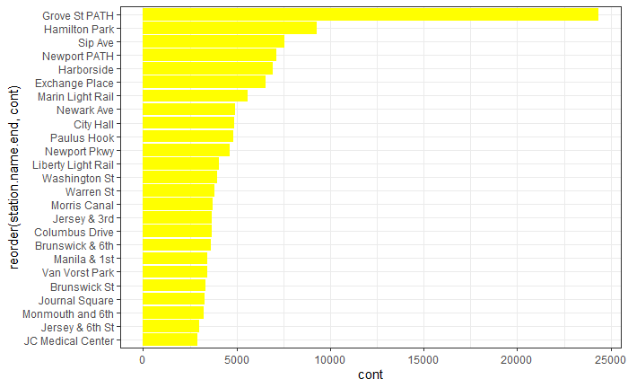

```r
end_stations %>%
  ggplot2::ggplot(ggplot2::aes(x = reorder(station.name.end,cont),y=cont))+
  ggplot2::geom_col(fill="yellow")+
  ggplot2::coord_flip()+
  ggplot2::theme_bw()
```

```r
NA
NA
```

Hay 26 estaciones de origen y 25 de destino que tienen el 80% de los usos. Por encima de todas destaca Grove St PATH.

Vamos a ver como se distribuye el tiempo total de uso por bicicleta. # Uso de bicicletas

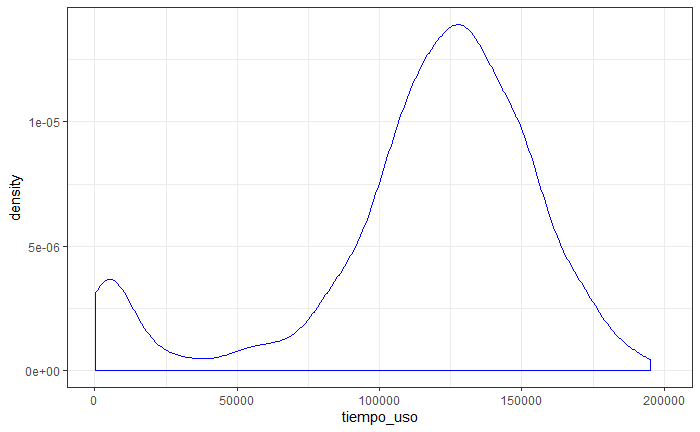

A ver como evoluciona el uso por meses… # Uso del servicio por meses

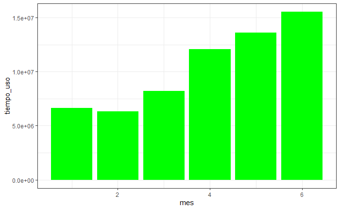

```r
rutas_mes <- rutas_geo %>%
  dplyr::mutate(mes=lubridate::month(starttime)) %>%
  dplyr::group_by(mes) %>%
  dplyr::filter(mes %in% c(1:6)) %>%
  dplyr::summarise(tiempo_uso=sum(tripduration))

rutas_mes %>%
  ggplot2::ggplot(ggplot2::aes(x=mes, y=tiempo_uso))+
  ggplot2::geom_col(fill="green")+
  ggplot2::theme_bw()
```

```r
NA
```

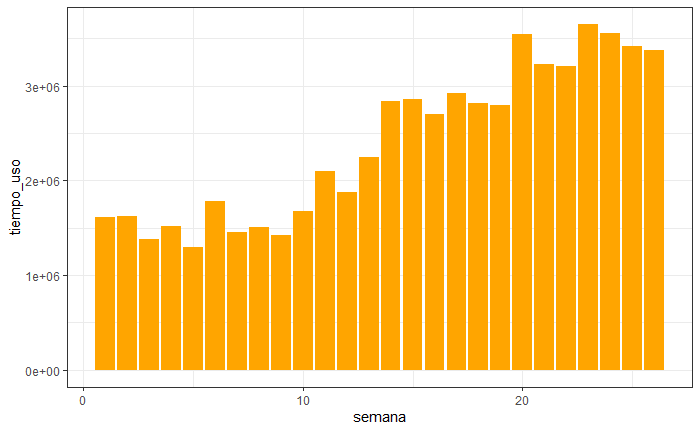

```r
rutas_semana <- rutas_geo %>%
  dplyr::mutate(semana=lubridate::week(starttime)) %>%
  dplyr::group_by(semana) %>%
  dplyr::filter(semana %in% c(1:26)) %>%
  dplyr::summarise(tiempo_uso=sum(tripduration))

rutas_semana %>%
  ggplot2::ggplot(ggplot2::aes(x=semana, y=tiempo_uso))+
  ggplot2::geom_col(fill="orange")+
  ggplot2::theme_bw()
```

Y por horas… # Uso del servicio por horas

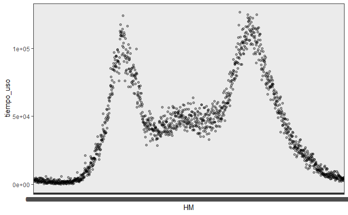